# Before and After Black Rock City

## Increased Open-Mindedness and Comparing Settings

# Evaluation of Increased Open-Mindedness* After Going to Black Rock City

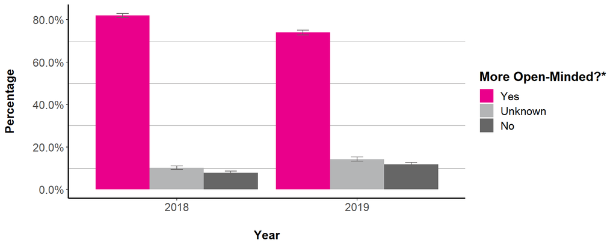

Error bars indicate the upper and lower bounds of the 95% confidence intervals.

* This question was first introduced in the 2018 online survey. The exact wording of this question in the online survey was, "Do you find yourself more open-minded and/or more willing to try new things after going to Black Rock City?"

|  | 2018 Percent | 2018 MoE +/- % |  | 2019 Percent | 2019 MoE +/- % |
| --- | --- | --- | --- | --- | --- |
| Yes | 82.0 | 1.0 |  | 74.0 | 1.2 |
| Unknown | 10.2 | 0.8 |  | 14.2 | 1.0 |
| No | 7.8 | 0.6 |  | 11.8 | 0.8 |

## Connection to Black Rock City

### Feelings of Connection to Black Rock City.*

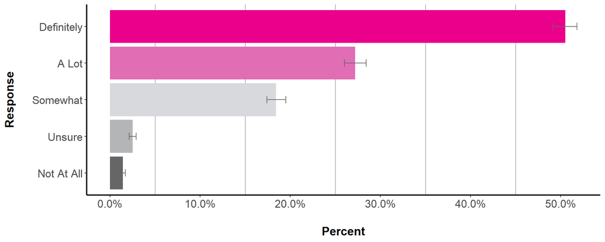

Error bars indicate the upper and lower bounds of the 95% confidence intervals.

*The actual wording for this question was "Experiencing a connection to Black Rock City can be described as feeling that the location of or experiences at the Burning Man event are special, important, or unique. This year, did you experience feelings of connection to Black Rock City?"  
This question was first asked in 2019.

|  | 2019 Percent | 2019 MoE +/- % |
| --- | --- | --- |
| Definitely | 50.5 | 1.4 |
| A Lot | 27.2 | 1.2 |
| Somewhat | 18.4 | 1.0 |
| Unsure | 2.5 | 0.4 |
| Not At All | 1.4 | 0.4 |

## Connection to Black Rock City

### Which Aspects of BRC did you Feel a Connection To?

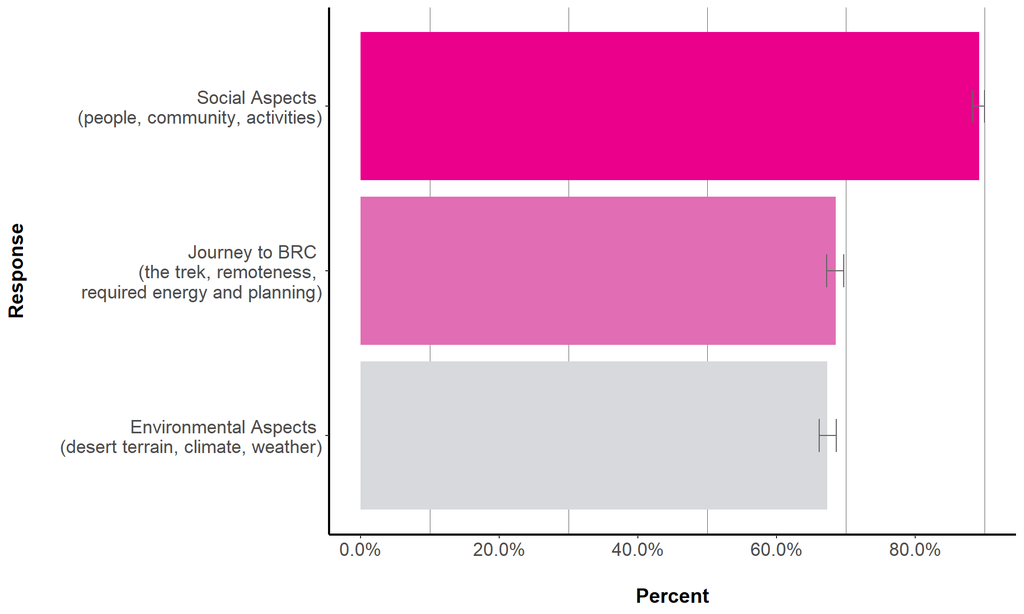

Error bars indicate the upper and lower bounds of the 95% confidence intervals.

Participants selected all option(s) that applied.  
*This question was first asked in 2019.

|  | 2019 Percent | 2019 MoE +/- % |
| --- | --- | --- |
| Social Aspects (people, community, activities) | 89.2 | 0.8 |
| Journey to BRC (the trek, remoteness, required energy and planning) | 68.5 | 1.2 |
| Environmental Aspects (desert terrain, climate, weather) | 67.3 | 1.2 |

## Connection to Black Rock City

### Impact of natural elements on the Burning Man experience.*

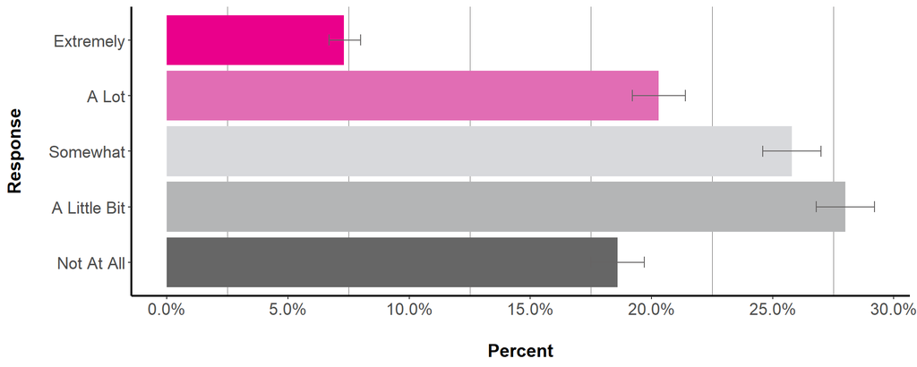

Error bars indicate the upper and lower bounds of the 95% confidence intervals.

*The actual wording for this question was "Did the natural elements (harsh climate, wind, dust. etc.) of the Black Rock Desert have an impact on your Burning Man experience?"  
This question was first asked in 2019.

|  | 2019 Percent | 2019 MoE +/- % |
| --- | --- | --- |
| Extremely | 7.3 | 0.6 |
| A Lot | 20.3 | 1.2 |
| Somewhat | 25.8 | 1.2 |
| A Little Bit | 28.0 | 1.2 |
| Not At All | 18.6 | 1.0 |

## Connection to Black Rock City

### Would Relocating Black Rock City Change the Experience?*

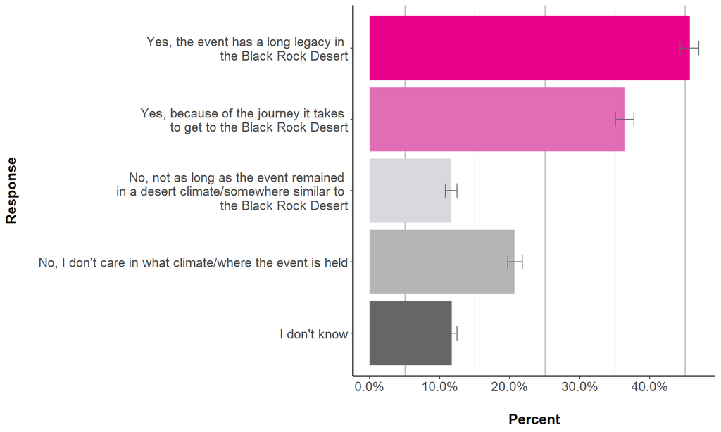

Error bars indicate the upper and lower bounds of the 95% confidence intervals.

Participants selected all option(s) that applied.  
*This question was first asked in 2019.

|  | 2019 Percent | 2019 MoE +/- % |
| --- | --- | --- |
| Yes, the event has a long legacy in the Black Rock Desert | 45.7 | 1.4 |
| Yes, because of the journey it takes to get to the Black Rock Desert | 36.4 | 1.4 |
| No, not as long as the event remained in a desert climate/somewhere similar to the Black Rock Desert | 11.6 | 0.8 |
| No, I don’t care in what climate/where the event is held | 20.7 | 1.2 |
| I don’t know | 11.7 | 0.8 |

**Next:** Before and After Black Rock City: Transformative Experience